# Wikipedia recommender system

Krzysztof Skrobała, Wojciech Bogacz

## ([Link to Github](https://github.com/shhhQuiettt/wikipedia-search-engine))

The aim of this project is to index the Wikipedia and build a **recommender system** in a simplified form on top of it. Given a list of previously read articles, the system should recommend the next article to read.

In this simplified form we assume that the documents are related, for example that they come from a **single session**, and we want to recommend the next article(s) to read.

### Process consists of following steps:

1. **Building the database**
   1. Downloading the Wikipedia dump
   2. Text Preprocessing
   3. Indexing
   4. Storing the index
2. **Recommending**
   1. Querying the read documents
   2. Calculating similarities
   3. Recommending the k-next articles

## Usage

- **1. Cloning the repository**

```
git clone --depth 1 https://github.com/shhhQuiettt/wikipedia-search-engine.git
cd wikipedia-search-engine
```

- **2. Creating virtual environment and downloading necessary packages**

```
python -m venv .venv
source .venv/bin/activate
pip install -r requirements.txt
```

- **2. Building the database**

Run this command to start the crawling and database building process:

```
python build_db.py
```

- **3. Recommending**

Put visited links inside `previously_seen.txt` and run this command to get 5 recommendations:

```
python recommender.py 5 previously_seen.txt
```

# Implementation

## Building the database

The building and indexing is done **asynchronously**. The crawling process is implemented in a coroutine model on a one thread ([`crawler.py`](https://github.com/shhhQuiettt/wikipedia-search-engine/blob/main/crawler.py)), while the indexing is done in a separate thread with multiple workers ([`indexing.py`](https://github.com/shhhQuiettt/wikipedia-search-engine/blob/main/indexing.py)).

### Downloading the Wikipedia dump

The crawler start from **three initial urls** to:

- An *important* mathematical theorem: [Hairy Ball Theorem](https://en.wikipedia.org/wiki/Hairy_ball_theorem)
- Butterjelly sandwich: [Butterjelly sandwich](https://en.wikipedia.org/wiki/Butterjelly_sandwich)
- Hedgehog: Hedgehog

Then `BeautifulSoup` is used to parse the html and extract the text from the body of the document. We also extract the title of the document. The document gets inside a queue, where it will await **preprocessing and indexing**, and we search for all urls in the body to apply the procedure recursively.

### Text Preprocessing

The text is preprocessed in the following way:

1. **Tokenization**

We tokenize the text using `nltk`’s `word_tokenize` function to obtain a list of tokens.

2. **Lemmatization**

We lemmatize the tokens using `nltk`’s `WordNetLemmatizer` to extract the base word of the token. For example the word “running” will be lemmatized to “run”.

3. **Stopwords removal**

We remove the stopwords using `nltk`’s `stopwords` list.

### Indexing

We want to store **TF-IDF** values for each word in document:

$$\text{TF}\left( \text{term},\text{document} \right) = \frac{\text{\# term appears in document}}{\text{\# the most frequent term in document}}$$

$$\text{IDF}\left( \text{term} \right) = \log\left( \frac{\text{total number of documents}}{\text{number of documents containing term}} \right)$$

$$\text{TF-IDF}\left( \text{term},\text{document} \right) = \text{TF}\left( \text{term},\text{document} \right) \times \text{IDF}\left( \text{term} \right)$$

The **IDF** is important in order to prioritize terms with **high entropy** among other documents

### Storing the index

In the current implementation we store inverted index inside **sqlite** database, but we abstract the index storage to an *abstract class* `InvertedIndex` to possibly test other storage methods like **NoSQL** databases like *mongoDB* or **RAM-base** like *Redis*

# Recommending

The read documents are queried from the database and the similarities are calculated using the **cosine similarity**. The cosine similarity is calculated as follows:

$$\text{cosine similarity}\left( \text{doc1},\text{doc2} \right) = \frac{\text{doc1} \cdot \text{doc2}}{\parallel \text{doc1} \parallel \times \parallel \text{doc2} \parallel}$$

Where document vector is a vector of **TF-IDF** values for each word in the document.

The implementation allows for using other similarity measures which fulfill the `similarity_function` interface (`recommender.py`), so we also tested **Jaccard similarity** with binary vectors:

$$\text{Jaccard similarity}\left( \text{doc1},\text{doc2} \right) = \frac{\text{doc1} \cap \text{doc2}}{\text{doc1} \cup \text{doc2}}$$

In the currenct implementation we assume that the documents come from a **single session** and we want to recommend the next `k` article(s) to read.

We calculate the **centroid** of the read documents and recommend the `k` closest documents to the centroid.

# Some recommendations

### 1. This session relates to **Mathematitics** and pioneers of **Calculus**

```python
!cat ./example_visited/previously_seen1.txt
```

```
https://en.wikipedia.org/wiki/Leonhard_Euler
https://en.wikipedia.org/wiki/Isaac_Newton
https://en.wikipedia.org/wiki/Mathematics
https://en.wikipedia.org/wiki/Functions_(mathematics)
https://en.wikipedia.org/wiki/Real_number
```

```python
!python recommender.py 5 ./example_visited/previously_seen1.txt
```

```
https://en.wikipedia.org/wiki/Leonhard_Euler not found in the database. Calculating document vector...
https://en.wikipedia.org/wiki/Isaac_Newton not found in the database. Calculating document vector...
Best ids: [(240, 0.06210137608606608), (258, 0.0590626066522234), (79, 0.054672164284898996), (322, 0.05021229255088811), (184, 0.04862576791724621)]
Recommended documents:
(240, 'https://en.wikipedia.org/wiki/Hyperreal_numbers', 'Hyperreal number')
Cosine similarity: 0.06210137608606608

(258, 'https://en.wikipedia.org/wiki/Theorem', 'Theorem')
Cosine similarity: 0.0590626066522234

(79, 'https://en.wikipedia.org/wiki/Calculus', 'Calculus')
Cosine similarity: 0.054672164284898996

(322, 'https://en.wikipedia.org/wiki/Bijective', 'Bijection')
Cosine similarity: 0.05021229255088811

(184, 'https://en.wikipedia.org/wiki/Mathematical_analysis', 'Mathematical analysis')
Cosine similarity: 0.04862576791724621
```

We see topics we would expect for someone interested in **Newton** and **Euler** and **Mathematics**

### 2. This session relates sandwiches

```python
!cat ./example_visited/previously_seen2.txt
```

```
https://en.wikipedia.org/wiki/Peanut_butter
https://en.wikipedia.org/wiki/Lunch
https://en.wikipedia.org/wiki/Sandwich
```

```python
!python recommender.py 5 ./example_visited/previously_seen2.txt
```

```
Best ids: [(560, 0.23502137689424202), (605, 0.20909613026041712), (599, 0.19268899828898028), (583, 0.19119226566432948), (800, 0.18548005955094318)]
Recommended documents:
(560, 'https://en.wikipedia.org/wiki/Bal%C4%B1k_ekmek', 'Balık ekmek')
Cosine similarity: 0.23502137689424202

(605, 'https://en.wikipedia.org/wiki/Roujiamo', 'Roujiamo')
Cosine similarity: 0.20909613026041712

(599, 'https://en.wikipedia.org/wiki/Panini_(sandwich)', 'Panini (sandwich)')
Cosine similarity: 0.19268899828898028

(583, 'https://en.wikipedia.org/wiki/Donkey_burger', 'Donkey burger')
Cosine similarity: 0.19119226566432948

(800, 'https://en.wikipedia.org/wiki/Bag_lunch', 'Packed lunch')
Cosine similarity: 0.18548005955094318
```

Indeed, we see different types of sandwiches someone could be interested in

# Some statistics and exploration of the results

```python
import matplotlib.pyplot as plt
from indexing import SqliteInvertedIndex
import recommender
from recommender import jacard_similarity, cosine_similarity
import numpy as np
```

```python
inverted_index = SqliteInvertedIndex("inverted_index.db")
inverted_index_matrix = inverted_index.get_tf_idf_matrix()

query = lambda query_text: inverted_index.cursor.execute(query_text)
```

## Number of documents

```python
query("select count(*) from documents").fetchone()
```

```
(1000,)
```

### Number of terms

```python
query("select count(*) from terms").fetchone()
```

```
(116470,)
```

```python
res = query(
    """
    select term, sum(count)
    from postings p
    join terms t on p.term_id = t.id
    group by term
    having length(term) > 3
    order by sum(count) desc
    limit 10
            """
)
res.fetchall()
```

```
[('shrew', 32304),
 ('function', 14177),
 ('retrieved', 12128),
 ('edit', 11623),
 ('space', 8069),
 ('isbn', 7562),
 ('also', 7100),
 ('archived', 6817),
 ('original', 6753),
 ('number', 6483)]
```

Despite weirdness of *shrew*, and manually checking, it turns out that *shrew* **indeed is** a frequent word in the documents related to mammals and other animals

### Terms with lowest entropy

```python
query(
    """
        select term, idf from terms order by idf asc limit 10
        """
).fetchall()
```

```
[('retrieved', 0.0),
 ('http', 0.0),
 ('1', 0.022245608947319737),
 ('reference', 0.03978087001184446),
 ('edit', 0.06935007813479324),
 ('2', 0.08773891430800689),
 ('also', 0.1266976530459575),
 ('3', 0.1636960926707897),
 ('see', 0.1779312084926618),
 ('new', 0.18632957819149354)]
```

### Terms with highest entropy

```python
query(
    """
  select term, idf from terms order by idf desc limit 10
  """
).fetchall()
```

```
[('combable', 6.907755278982137),
 ('ℝ3', 6.907755278982137),
 ('idealizes', 6.907755278982137),
 ('meteorologically', 6.907755278982137),
 ('accomplishes', 6.907755278982137),
 ('gidea', 6.907755278982137),
 ('1584882530', 6.907755278982137),
 ('abbildung', 6.907755278982137),
 ('bormashenko', 6.907755278982137),
 ('kazachkov', 6.907755278982137)]
```

### Distribution of terms occurance among all documents

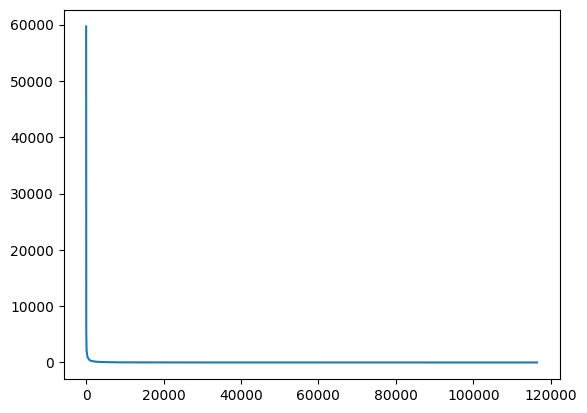

```python
res = query(
    """
        select t.term, sum(p.count)
        from terms t join postings p on t.id = p.term_id
        group by t.term
        order by sum(p.count) desc
    """
).fetchall()

plt.plot([x[1] for x in res])
```

### Checking if corpus fulfills Zipf's law

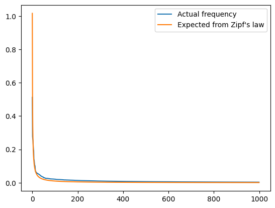

```python
res = query(
    """
    select t.term, sum(p.count)
    from terms t join postings p on t.id = p.term_id
    group by t.term
    order by sum(p.count) desc
    """
).fetchall()

ocurrances = np.array([x[1] for x in res])
N = len(ocurrances)
k = ocurrances[3] / N * 4
expected_zipf = k / np.arange(1, N + 1)

cut_off = 1000
plt.plot(ocurrances[:1000] / N)
plt.plot(expected_zipf[:1000])
plt.legend(["Actual frequency", "Expected from Zipf's law"])
```

### Documents most similar to the article **Open Set**

```python
url = "https://en.wikipedia.org/wiki/Open_set"
doc_id = inverted_index.get_document_id(url)
assert doc_id is not None

doc_vector = inverted_index_matrix[doc_id, :]

similarities = np.apply_along_axis(
    lambda x: cosine_similarity(doc_vector, x), 1, inverted_index_matrix
)

top_5_similarities = np.argsort(similarities, axis=0)[-6:-1]

for doc_id in top_5_similarities[::-1]:
    res = query(
        f"""
        select title from documents where id = {doc_id}
        """,
    ).fetchone()
    assert res is not None
    print(f"Title: {res[0]}")
    print(f"Cosine similarity: {similarities[doc_id]}\n")
```

```
Title: Open set
Cosine similarity: 1.0

Title: Closed set
Cosine similarity: 0.1670939050012435

Title: Accumulation point
Cosine similarity: 0.09399570728349808

Title: Open and closed maps
Cosine similarity: 0.09323925622985396

Title: Open and closed maps
Cosine similarity: 0.09323925622985396
```

### Documents least similar document to the article **Open set**

```python
url = "https://en.wikipedia.org/wiki/Open_set"
doc_id = inverted_index.get_document_id(url)
assert doc_id is not None

doc_vector = inverted_index_matrix[doc_id, :]

similarities = np.apply_along_axis(
    lambda x: cosine_similarity(doc_vector, x), 1, inverted_index_matrix
)

top_5_similarities = np.argsort(similarities, axis=0)[:5]

for doc_id in top_5_similarities:
    res = query(
        f"""
        select title from documents where id = {doc_id}
        """,
    ).fetchone()
    assert res is not None
    print(f"Title: {res[0]}")
    print(f"Cosine similarity: {similarities[doc_id]}\n")
```

```
Title: Eastern forest hedgehog
Cosine similarity: 4.099291536117715e-06

Title: Chacarero
Cosine similarity: 1.473436229790874e-05

Title: Somali hedgehog
Cosine similarity: 2.148079406048971e-05

Title: Hemiechinus
Cosine similarity: 2.2237134281189762e-05

Title: Gaoligong forest hedgehog
Cosine similarity: 2.259060627956648e-05
```

These results make sense, as Open Set relates to topics like *topology* and *closed sets*, while do not relate to topics like *hedgehogs* or *Chacarero*

**Open Set**:

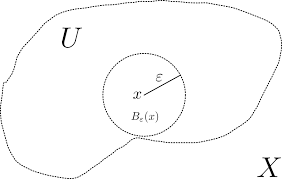

**Closed Set** (similar to Open Set):

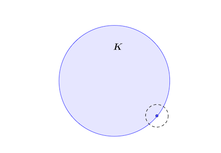

**Eastern forest hedgehog** (not similar to Open Set):

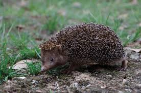

# Comparing similiarities between various documents

```python
hedghog_doc_url = "https://en.wikipedia.org/wiki/Hedgehog"
hedgehog_doc_id = inverted_index.get_document_id(hedghog_doc_url)
hedgehog_doc_vector = inverted_index_matrix[hedgehog_doc_id, :]
assert hedgehog_doc_vector is not None

calculus_doc_url = "https://en.wikipedia.org/wiki/Calculus"
calculus_doc_id = inverted_index.get_document_id(calculus_doc_url)
calculus_doc_vector = inverted_index_matrix[calculus_doc_id, :]
assert calculus_doc_vector is not None

derivatives_doc_url = "https://en.wikipedia.org/wiki/Derivative"
derivatives_doc_id = inverted_index.get_document_id(derivatives_doc_url)
derivatives_doc_vector = inverted_index_matrix[derivatives_doc_id, :]
assert derivatives_doc_vector is not None
```

### Cosine similarity and Jacard similarity between hedgehog and calculus

```python
cosine_similarity_score = cosine_similarity(hedgehog_doc_vector, calculus_doc_vector)
jacard_similarity_score = jacard_similarity(hedgehog_doc_vector, calculus_doc_vector)

print("Hedgehog vs Calculus")
print(f"Cosine similarity: {cosine_similarity_score}")
print(f"Jacard similarity: {jacard_similarity_score}")
```

```
Hedgehog vs Calculus
Cosine similarity: 0.0036931801887427344
Jacard similarity: 0.09270638525247128
```

### Cosine similarity and Jacard similarity between calculus and derivatives

```python
cosine_similarity_score = cosine_similarity(calculus_doc_vector, derivatives_doc_vector)
jacard_similarity_score = jacard_similarity(calculus_doc_vector, derivatives_doc_vector)
print("Calculus vs Derivatives")
print(f"Cosine similarity: {cosine_similarity_score}")
print(f"Jacard similarity: {jacard_similarity_score}")
```

```
Calculus vs Derivatives
Cosine similarity: 0.04768521737485992
Jacard similarity: 0.27093206951026855
```

### The results and the quality of recommender would be higher for more documents than only 1000. To increase this number, before building the DB one could change `TOTAL_PAGES` in [`build_db.py`](https://github.com/shhhQuiettt/wikipedia-search-engine/blob/main/build_db.py)